# Ford GoBike System Dateset¶

## by Fahad AlQahtani

## Investigation Overview

In this Investigation I'm interested on figuring out about the relationship for the age of riders and user type , gender the duration that they can achieve.

## Dataset Overview

There are 718,994 data trips for fordgobike in the dataset with 18 features (trip_duration, start_time, stop_time, start_station_id, start_station_name, start_station_latitude, start_station_longitude, end_station_id, end_station_name, end_station_latitude ,end_station_longitude, bike_id, user_type,birth_year,gender). I've added some columns to help me investigate my data easier (User_age,start_time_hour,stop_time_hour). The data types are category(3), datetime64 ns(2), float64(5), int64(4), object(4).

## Distribution of Gender

The bar chart shows that the male user has the most number of users.

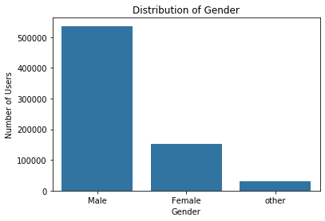

```python
# create a bar chart to find the number of user by their gender
base_color = sns.color_palette()[0]
gender_order = df['gender'].value_counts().index
sns.countplot(data = df, x = 'gender', color = base_color,order =gender_order)
plt.title('Distribution of Gender')
plt.xlabel('Gender')
plt.ylabel('Number of Users');
```

## Distribution of Age

The bar chart shows that 51 years old is the age group most frequently reported in the data.

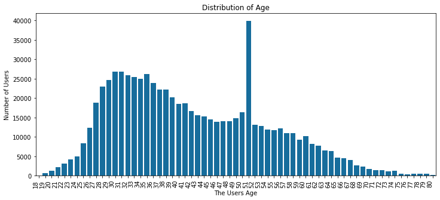

```python
# create a bar chart to find the number of user by their age
base_color = sns.color_palette('colorblind')[0]
plt.figure(figsize=(12,5))
chart = sns.countplot(data=df, x='User_age',color=base_color);
plt.title('Distribution of Age')
plt.xlabel('The Users Age');
plt.ylabel('Number of Users');
chart.set_xticklabels(chart.get_xticklabels(), rotation=90, horizontalalignment='right');
```

## Distribution of Trip Start Hour of Day

Obviously most of people use the bike from 17:00 to 18:00

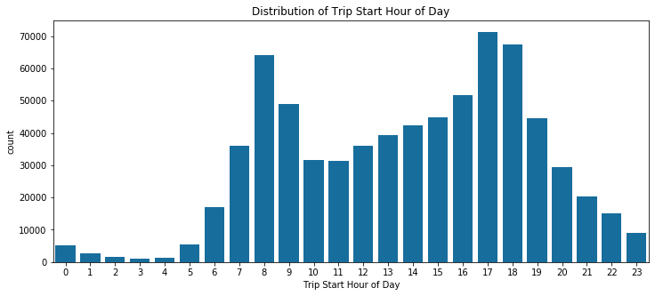

```python
# plot the Distribution of Trip Start Hour of Day
plt.figure(figsize=[12, 5]);
base_color = sns.color_palette('colorblind')[0]

sns.countplot(df['start_time_hour'], color = base_color)
plt.xlabel('Trip Start Hour of Day');
plt.title('Distribution of Trip Start Hour of Day');
```

## Distribution of Trip Durations

the histogram doesn't make any sense so I'm gonna go deeper by converting the scales and transformations.

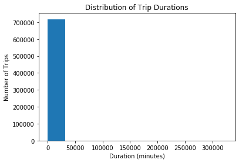

```python
# draw a histogram for Distribution of Trip Durations
plt.hist(data = df, x = 'trip_duration');
plt.title('Distribution of Trip Durations')
plt.xlabel('Duration (minutes)')
plt.ylabel('Number of Trips');
```

## Distribution of Trip Durations

The histogram has a normal distrabution and shows that the peak trip duration was on 8 to 10 minutes

```python
#limiting the minutes of trip_duration to 150 or less
df = df[df['trip_duration'] <= 150]
df.info()
```

```
<class 'pandas.core.frame.DataFrame'>
Int64Index: 717116 entries, 0 to 718993
Data columns (total 18 columns):
 #   Column                   Non-Null Count   Dtype
---  ------                   --------------   -----
 0   trip_duration            717116 non-null  float64
 1   start_time               717116 non-null  datetime64[ns]
 2   stop_time                717116 non-null  datetime64[ns]
 3   start_station_id         717116 non-null  category
 4   start_station_name       717116 non-null  object
 5   start_station_latitude   717116 non-null  float64
 6   start_station_longitude  717116 non-null  float64
 7   end_station_id           717116 non-null  category
 8   end_station_name         717116 non-null  object
 9   end_station_latitude     717116 non-null  float64
 10  end_station_longitude    717116 non-null  float64
 11  bike_id                  717116 non-null  category
 12  user_type                717116 non-null  object
 13  birth_year               717116 non-null  int64
 14  gender                   717116 non-null  object
 15  User_age                 717116 non-null  int64
 16  start_time_hour          717116 non-null  int64
 17  stop_time_hour           717116 non-null  int64
dtypes: category(3), datetime64[ns](2), float64(5), int64(4), object(4)
memory usage: 92.1+ MB
```

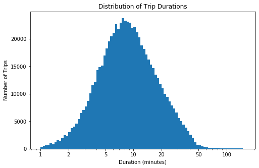

```python
# draw a histogram for Distribution of Trip Durations
bins = 10 ** np.arange(0, np.log10(df['trip_duration'].max())+0.025, 0.025)
plt.figure(figsize=[8, 5]);
plt.hist(data = df, x = 'trip_duration', bins = bins);
plt.xscale('log');
plt.xticks([1, 2, 5, 10, 20, 50, 100], [1, 2, 5, 10, 20, 50, 100]);
plt.title('Distribution of Trip Durations')
plt.ylabel('Number of Trips')
plt.xlabel('Duration (minutes)');
```

## Trip Duration and Age

As we can see there is no clear relationship between the two variables But for the people on age 51 there is a kind of relationship.

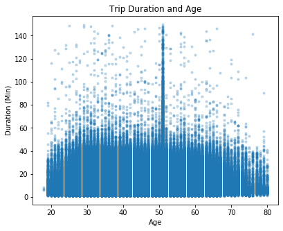

```python
plt.figure(figsize=[14,5]);
#plot scatter without the mean
plt.subplot(1, 2, 1)
plt.scatter(data = df,x ='User_age', y ='trip_duration', alpha = 0.25, marker = '.' )
plt.title('Trip Duration and Age')
plt.xlabel('Age')
plt.ylabel('Duration (Min)')
```

## Trip Duration and User Type

we can see that higher percentage of customer rides longer trips then subscriber.

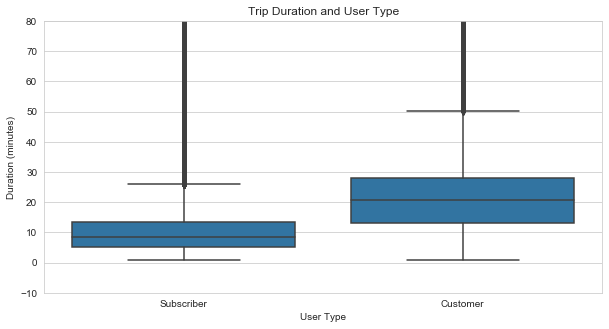

```python
# draw boxplot for Trip Duration and user_type
plt.figure(figsize = [10, 5])
sns.set_style("whitegrid")
base_color = sns.color_palette()[0]
sns.boxplot(data = df, x = 'user_type', y = 'trip_duration', color = base_color)
plt.ylim([-10, 80])
plt.title('Trip Duration and User Type')
plt.xlabel('User Type')
plt.ylabel('Duration (minutes)')
plt.show()
```

## Trip Duration, Gender, and Age

The graph shows that there is an accumulation of data for both males and females between 0 to 40 minutes while the other has the highest trip duration for aged 51.

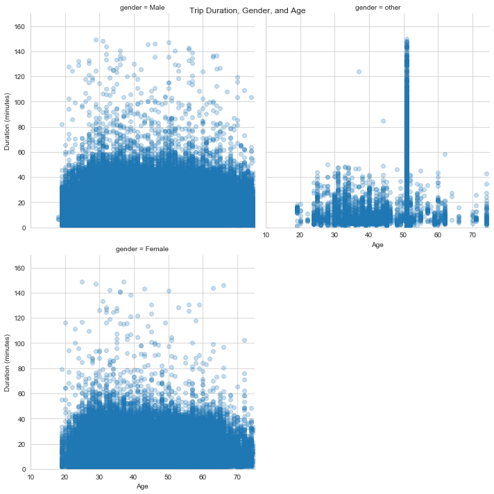

```python
# draw scatter for Trip Duration, Gender, and Age
gender = sns.FacetGrid(data = df, col = 'gender', col_wrap = 2, height = 5,
                 xlim = [10, 75], ylim = [0, 170])
gender.map(plt.scatter, 'User_age', 'trip_duration', alpha= 0.25)
gender.set_xlabels('Age')
gender.set_ylabels('Duration (minutes)')
gender.fig.suptitle('Trip Duration, Gender, and Age')
plt.show();
```

## Trip Duration, User type, and Age

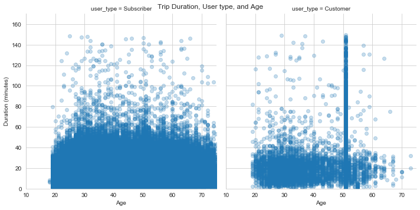

```python
# draw scatter for Trip Duration, User type, and Age
user_type = sns.FacetGrid(data = df, col = 'user_type', col_wrap = 2, height = 5,
                 xlim = [10, 75], ylim = [0, 170])
user_type.map(plt.scatter, 'User_age', 'trip_duration', alpha= 0.25)
user_type.set_xlabels('Age')
user_type.set_ylabels('Duration (minutes)')
user_type.fig.suptitle('Trip Duration, User type, and Age')
plt.show()
```